# Reproducible Research: Peer Assessment 1

## Introduction

This work is aimed to analyze data as established in specifications for Project 1 in Course 5 of the Data Science track at Coursera. The specifications, as well as the data, are part of the following github repo: https://github.com/rdpeng/RepData_PeerAssessment1. In that repo, the specifications are in file *README.md*, and the data to be analyzed is in file *activity.zip*. The data file was downloaded and decompressed (by “hand”) into the current working directory.

Other packages that shall be used are *dplyr*, *lubridate*, and *lattice*.

Now let’s work.

## Loading and preprocessing the data

Once the zip file is downloaded and decompressed, we get access to file *activity.csv*, which contains the data to be analyzed. From now on, the analysis to be presented here presumes that file *activity.csv* is located in the current working directory.

The data in *activity.csv* is read into a data frame named *activity*. For that, the following R code is used:

```r
activity <- read.csv("activity.csv")
```

The following are some initial exploratory operations to better understand the data.

Dimensions of the data are:

```r
dimsactivity <- dim(activity)
print(paste("Number of rows =", dimsactivity[1]))
```

```
## [1] "Number of rows = 17568"
```

```r
print(paste("Number of columns =", dimsactivity[2]))
```

```
## [1] "Number of columns = 3"
```

There is one row for every 5-minute period in all the days in the data set. The following R code is used to certify this.

```r
library(dplyr)
gactivityDate <- group_by(activity, date)
dataPerDay <- dplyr::summarise(gactivityDate, count = n())
nobs <- unique(dataPerDay$count)
if(length(nobs) == 1) {
      print(paste("There are ", nobs[1],
                  " observations for each day in the data set."))
      n = 24*60/5
      if(nobs[1]==n)
            print("This is exactly the number of 5-minute intervals in 24 hours.")
      else
            print(paste("The number of 5-minute intervals in 24 hours is", n, "."))
} else {
      print("Observations per day differ. Some of those numbers are:")
      print(nobs)
}
```

```
## [1] "There are  288  observations for each day in the data set."
## [1] "This is exactly the number of 5-minute intervals in 24 hours."
```

## What is mean total number of steps taken per day?

The following R code constructs a histogram of the number of steps taken per day. The intervals being used are as determined by the value of parameter *breaks* that R assigns by default. Different histograms can be generated by just adding the corresponding “breaks” value. The *mean* and the *median* of the total number of steps taken per day are also shown in the histogram panel as lines, as well as values.

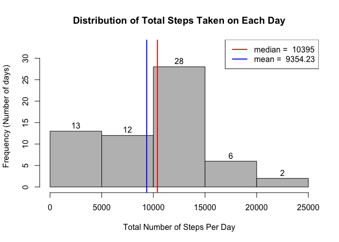

```r
library(dplyr)
## determine the total number of steps taken on each day in the data set
## these totals are saved in data frame sactivityDate
gactivityDate <- group_by(activity, date)
sactivityDate <-
      dplyr::summarise(gactivityDate, totalSteps = sum(steps, na.rm = TRUE))
h <- hist(sactivityDate$totalSteps, plot = FALSE)
plot(h, main="Distribution of Total Steps Taken on Each Day",
     ylim = c(0, max(h$counts)+5), ylab = "Frequency (Number of days)",
     xlab = "Total Number of Steps Per Day", col = "gray", labels = TRUE)
md <- round(median(sactivityDate$totalSteps), 2)  # median of total steps per day
mn <- round(mean(sactivityDate$totalSteps), 2)    # mean of total steps per day
abline(v=md, col = "red", lwd=2)  # display horizontal line for median
abline(v=mn, col="blue", lwd=2)   # display horizontal line for mean
legend("topright", lty=1, lwd=2, legend=c(paste("median = ", md),
                                     paste("mean = ", mn)),
                                     col = c("red", "blue"))
```

## What is the average daily activity pattern?

To explore the average daily activity, we want to determine the average number of steps taken on each 5-minute interval. For this, we will do the following:

1. Make a time series plot of the 5-minute intervals (x-axis) and the average number of steps taken, averaged across all days (y-axis).
2. Show the 5-minute interval, on average across all the days in the data set, containing the maximun number of steps. If more than one, it shows all the corresponding intervals.

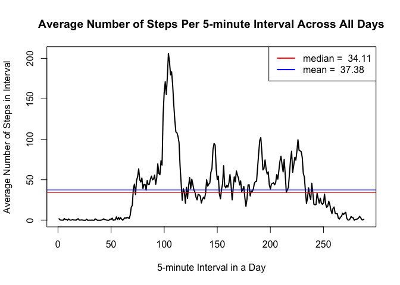

```r
library(dplyr)
## determine the average number of steps taken on each 5-minute interval
## accross all days in the data set and discarding missing values
## These averages are computed in data frame sactivityInterval
gactivityInterval <- group_by(activity, interval)
sactivityInterval <-
      dplyr::summarise(gactivityInterval,
                       averageSteps = mean(steps, na.rm = TRUE))
## assign index value 1..288 to each 5-minute interval
sactivityInterval$intervalNumber <- 1:nrow(sactivityInterval)
plot(sactivityInterval$intervalNumber, sactivityInterval$averageSteps,
     type = "l", lwd=2, xlab = "5-minute Interval in a Day",
     ylab = "Average Number of Steps in Interval")
md <- round(median(sactivityInterval$averageSteps), 2)
mn <- round(mean(sactivityInterval$averageSteps), 2)
abline(h=md, col = "red")
abline(h=mn, col="blue")
title(main="Average Number of Steps Per 5-minute Interval Across All Days")
legend("topright", lty=1, lwd=2, legend=c(paste("median = ", md),
                                     paste("mean = ", mn)),
                                     col = c("red", "blue"))
```

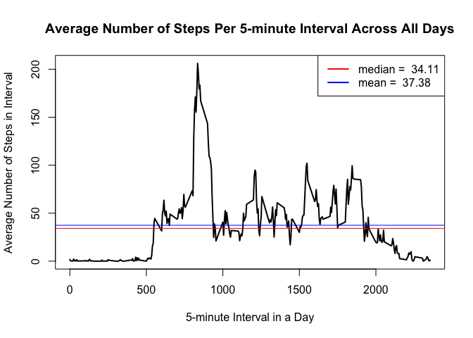

```r
## same as previous chunk, but this time the x-axis uses labels corresponding
## to the values of interval as in the data set, not indexes 1:288 as in that
## chunk.
plot(sactivityInterval$interval, sactivityInterval$averageSteps,
     type = "l", lwd=2, xlab = "5-minute Interval in a Day",
     ylab = "Average Number of Steps in Interval")
md <- round(median(sactivityInterval$averageSteps), 2)
mn <- round(mean(sactivityInterval$averageSteps), 2)
abline(h=md, col = "red")
abline(h=mn, col="blue")
title(main="Average Number of Steps Per 5-minute Interval Across All Days")
legend("topright", lty=1, lwd=2, legend=c(paste("median = ", md),
                                     paste("mean = ", mn)),
                                     col = c("red", "blue"))
```

The following produces the 5-minute period(s) containing the maximum number of steps.

```r
library(lubridate)
maxSteps <- max(sactivityInterval$averageSteps)
maxStepsPeriod <- subset(sactivityInterval, averageSteps == maxSteps)
print(paste("The 5-minute period with maximum average number of steps is: interval",
            maxStepsPeriod$intervalNumber))
```

```
## [1] "The 5-minute period with maximum average number of steps is: interval 104"
```

```r
print(paste("This corresponds to the following interval as in the original data:",
            maxStepsPeriod$interval))
```

```
## [1] "This corresponds to the following interval as in the original data: 835"
```

```r
h <- maxStepsPeriod$interval
print(paste("In both cases, the hour of the day with that maximum value is: ",
            hm(paste(trunc(h/100), h%%100, sep = ":"))))
```

```
## [1] "In both cases, the hour of the day with that maximum value is:  8H 35M 0S"
```

```r
print(paste("The maximum average number of steps per period is: ", round(maxSteps, 2)))
```

```
## [1] "The maximum average number of steps per period is:  206.17"
```

## Imputing missing values

At this stage, we want to estimate and add values to those missing values in the original data set. We can use the following loop to count how many rows contain NA values for each variable in the data frame.

```r
nm <- names(activity)
for(v in 1:length(nm)) {
      nmv <- sum(is.na(activity[, v]))
      if (nmv > 0)
            print(paste("Variable", nm[v], "has ", nmv, "missing values."))
}
```

```
## [1] "Variable steps has  2304 missing values."
```

We can see that only variable *steps* has missing values. In total, there are 2304 missing values of that variable.

To assign a value to all those observations in which the value of the variable *steps* is missing, what we will do is the following. To the 5-minute period p for a particular day x in which the value of *steps* is NA, we will assign the current average number of steps taken across all instances in the data set corresponding to the same day of the week as day x and same period p after discarting the NA values. In those cases (if any) in which all the values are missing, we shall assign value 0.

First, we add a new column to *activity* data frame. Such column will have values 1..7, identifying the *day of the week* that the particular observation corresponds to as per the value of *date*. The name of the new column is *wdayNumber* and it is of type *integer*. This is achieved with the following R code:

```r
library(lubridate)
activity$wdayNumber <- wday(activity$date)   ## 1 Sunday, 2 Monday, ... 7  Sat
```

The next R code constructs a temporary data frame containing the estimaded values to substitute the NA values as per the previously described strategy. The new data frame’s name is *sactivityWDayInterval*, in which column *missingSteps* contains the estimated value for the 5-minute interval that the particular row corresponds to. The displayed result shows tha no estimated value is NA.

```r
gactivityWDayInterval <- group_by(activity, wdayNumber, interval)
sactivityWDayInterval <-
      dplyr::summarise(gactivityWDayInterval,
                       missingSteps = mean(steps, na.rm = TRUE))
print(paste("Number of NA values in missingSteps is:",
      sum(is.na(sactivityWDayInterval$missingSteps))))
```

```
## [1] "Number of NA values in missingSteps is: 0"
```

Note that there is an estimated missing value for every period on each different day of the week. That is, there are 288*7=2016 rows in the new data frame.

```r
dim(sactivityWDayInterval)
```

```
## [1] 2016    3
```

For each row in the *activity* data frame in which the number of steps is NA as per the original data, we assign the missing value that was computed for such period and the particular day of the week that the row corresponds to. This new version of the data is saved in a new data frame called *actividy2*. The following R code does it.

```r
activity2 <- merge(activity, sactivityWDayInterval)
naStepIndexes <- is.na(activity2$steps)
activity2[naStepIndexes,]$steps <- activity2[naStepIndexes,]$missingSteps
activity$missingSteps <- NULL
```

Using the new data, which include the estimated values, the next code makes a *histrogram of the total number of steps taken each day*, and reports its *mean* and *median* values after adding estimated values for those that were missing.

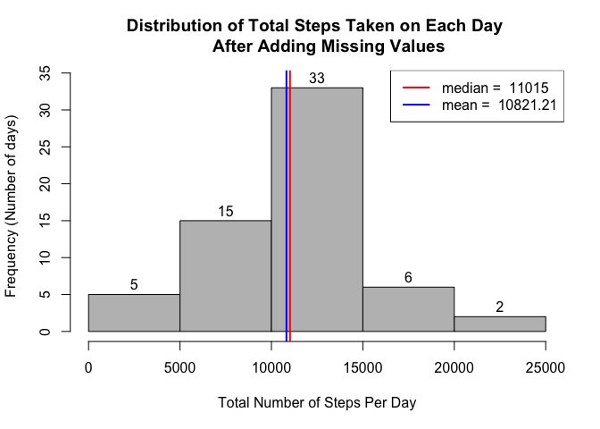

```r
library(dplyr)
gactivityDate <- group_by(activity2, date)
sactivityDate <- dplyr::summarise(gactivityDate,
                                  totalSteps = sum(steps, na.rm = TRUE))
h <- hist(sactivityDate$totalSteps, plot = FALSE)
plot(h,
     main="Distribution of Total Steps Taken on Each Day
     After Adding Missing Values",
     ylim = c(0, max(h$counts)+1), ylab = "Frequency (Number of days)",
     xlab = "Total Number of Steps Per Day", col = "gray", labels = TRUE)
md <- round(median(sactivityDate$totalSteps), 2)
mn <- round(mean(sactivityDate$totalSteps), 2)
abline(v=md, col = "red", lwd=2)
abline(v=mn, col="blue", lwd=2)
legend("topright", lty=1, lwd=2, legend=c(paste("median = ", md),
                                     paste("mean = ", mn)),
                                     col = c("red", "blue"))
```

As can be observed from the output graphs, there is substantial change in those days in which less than 15,000 steps were taken. The new data increases the values of mean and median of the total number of steps taken on each day when compared to the orinal data in which the missing values were discarded.

```r
daysWithNASteps <- subset(activity, is.na(steps))
gdaysWithNAStepsDate <- group_by(daysWithNASteps, date)
sdaysWithNASteps <- dplyr::summarise(gdaysWithNAStepsDate, countNAPeriods = n())
sdaysWithNASteps
```

```
## # A tibble: 8 x 2
##         date countNAPeriods
##       <fctr>          <int>
## 1 2012-10-01            288
## 2 2012-10-08            288
## 3 2012-11-01            288
## 4 2012-11-04            288
## 5 2012-11-09            288
## 6 2012-11-10            288
## 7 2012-11-14            288
## 8 2012-11-30            288
```

As we can see, only 8 days are reported. Moreover, in all those days, all 5-minute periods have missing value for variable *steps*. Hence, in the original data, these were part of the 13 days shown for the interval [0, 5000]. This is so because the expression *sum(x, na.rm=TRUE)* returns 0 if all entries in x are NA.

Notice also that in the new histogram (after adding the estimated values), there are only 5 days in the range [0, 5000]. This means that the estimated values put all those 8 days in one of the following ranges: [5000, 10000] or [10000, 15000]. We can explore this in more detail by using the following R code.

```r
daysOfEstimatedSteps <-
      subset(activity2, is.element(date, sdaysWithNASteps$date))
gdaysOESDate <- group_by(daysOfEstimatedSteps, date)
sdaysOESDate <- dplyr::summarise(gdaysOESDate, totalSteps = sum(steps))
sdaysOESDate
```

```
## # A tibble: 8 x 2
##         date totalSteps
##       <fctr>      <dbl>
## 1 2012-10-01   9974.857
## 2 2012-10-08   9974.857
## 3 2012-11-01   8212.750
## 4 2012-11-04  12277.714
## 5 2012-11-09  12359.714
## 6 2012-11-10  12535.429
## 7 2012-11-14  11790.750
## 8 2012-11-30  12359.714
```

And here we can see what really happened after adding the estimated number of steps to those 5-minute periods having NA value for variable *steps*. Note that *three* of them now are in the range [5000, 10000] and *five* are in the range [10000, 15000]. That explains why the original histogram (when NA values were discarded) changes to the new one after the missing values are estimated.

## Are there differences in activity patterns between weekdays and weekends?

Now let’s add a new column to the *activity2* data frame. This is a column of type *factor* and two levels: *weekend* and *weekday*. It classifies each of the observations in the *activity2* data frame depending to the day of the week that its date corresponds to.

```r
library(lubridate)
weekendDays <- activity2$wdayNumber == 1 | activity2$wdayNumber == 7
activity2$dayType <- "weekday"
activity2[weekendDays,]$dayType = "weekend"
activity2$dayType <- as.factor(activity2$dayType)
```

And verifying how many of the observations belongs to each of the two categories, we get the following:

```r
table(activity2$dayType)
```

```
##
## weekday weekend
##   12960    4608
```

To compare patterns in weekdays vs weekends we generate the next two plots, one for week days (Monday trhough Friday) and another for weekend days. In both, the plot shows the average number of steps per 5-minute periods during the day. Data used is the data in *activity2*, which include the estimated values for those that were missing in the original data.

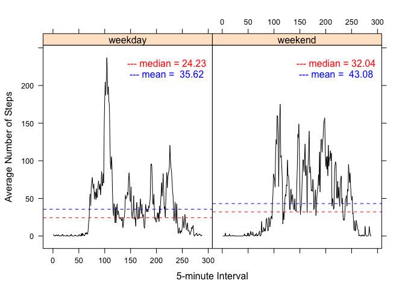

```r
library(lattice)
library(dplyr)
gactivityDaytypeInterval <- group_by(activity2, dayType, interval)
sactivityDaytypeInterval <- dplyr::summarise(gactivityDaytypeInterval,
                                             average=mean(steps,
                                                          na.rm = TRUE))
sactivityDaytypeInterval$intervalNumber <-
      rep(1:(nrow(sactivityDaytypeInterval)/2), 2)

with(sactivityDaytypeInterval,
     xyplot(average~intervalNumber|dayType, type = "l", col="black",
            panel = function(x, y) {
                  lcolor <- c("red", "blue")
                  panel.xyplot(x, y, type = "l", col = "black")
                  panel.abline(h=median(y), col=lcolor[1], lty=2)  ## median
                  panel.abline(h=mean(y), col=lcolor[2], lty=2)  ## mean

                  # adding a legend to each panel
                  infText1 <- paste("--- median =", round(median(y),2))
                  infText2 <- paste("--- mean = ", round(mean(y),2))
                  panel.text(220, 230, labels=c(infText1, 1),  col=lcolor[1])
                  panel.text(220, 215 , labels=c(infText2, 2),  col=lcolor[2])
            },
            xlab = "5-minute Interval",
            ylab = "Average Number of Steps")
     )
```

The values, as well as corresponding horizontal lines, for the median and the mean are included in the corresponding panel.